# 628hw2

```r
corandcov2(m4)
```

```
## Marginal variance covariance matrix
##        [,1]   [,2]   [,3]   [,4]
## [1,] 5.2465 3.2280 1.9861 1.2220
## [2,] 3.2280 5.2465 3.2280 1.9861
## [3,] 1.9861 3.2280 5.2465 3.2280
## [4,] 1.2220 1.9861 3.2280 5.2465
##   Standard Deviations: 2.2905 2.2905 2.2905 2.2905
```

```
##           [,1]      [,2]      [,3]      [,4]
## [1,] 1.0000000 0.6152662 0.3785526 0.2329106
## [2,] 0.6152662 1.0000000 0.6152662 0.3785526
## [3,] 0.3785526 0.6152662 1.0000000 0.6152662
## [4,] 0.2329106 0.3785526 0.6152662 1.0000000
```

```r
m5 <- gls(Dental_growth ~ Gender*agefactor, data=longdata,
          corr=corARMA(form= ~ Time | ID, p=3, q=0))
summary(m5)
```

```
## Generalized least squares fit by REML
##   Model: Dental_growth ~ Gender * agefactor
##   Data: longdata
##        AIC      BIC   logLik
##   442.9499 474.2119 -209.475
##
## Correlation Structure: ARMA(3,0)
##  Formula: ~Time | ID
##  Parameter estimate(s):
##       Phi1       Phi2       Phi3
##  0.3833924  0.5504612 -0.1454976
##
## Coefficients:
##                         Value Std.Error   t-value p-value
## (Intercept)         21.181818 0.6953977 30.460006  0.0000
## GenderM              1.693182 0.9033481  1.874340  0.0638
## agefactor10          1.045455 0.6010589  1.739355  0.0850
## agefactor12          1.909091 0.5391080  3.541203  0.0006
## agefactor14          2.909091 0.7176260  4.053770  0.0001
## GenderM:agefactor10 -0.107955 0.7807984 -0.138262  0.8903
## GenderM:agefactor12  0.934659 0.7003218  1.334614  0.1850
## GenderM:agefactor14  1.684659 0.9322235  1.807141  0.0737
##
##  Correlation:
##                     (Intr) GendrM agfc10 agfc12 agfc14 GnM:10 GnM:12
## GenderM             -0.770
## agefactor10         -0.432  0.333
## agefactor12         -0.388  0.298  0.448
## agefactor14         -0.516  0.397  0.679  0.574
## GenderM:agefactor10  0.333 -0.432 -0.770 -0.345 -0.523
## GenderM:agefactor12  0.298 -0.388 -0.345 -0.770 -0.442  0.448
## GenderM:agefactor14  0.397 -0.516 -0.523 -0.442 -0.770  0.679  0.574
##
## Standardized residuals:
##         Min          Q1         Med          Q3         Max
## -2.54728932 -0.60633616 -0.07883294  0.61095527  2.28985051
##
## Residual standard error: 2.306373
## Degrees of freedom: 108 total; 100 residual
```

```r
corandcov2(m5)
```

```
## Marginal variance covariance matrix
##        [,1]   [,2]   [,3]   [,4]
## [1,] 5.3194 3.3324 3.7209 2.4869
## [2,] 3.3324 5.3194 3.3324 3.7209
## [3,] 3.7209 3.3324 5.3194 3.3324
## [4,] 2.4869 3.7209 3.3324 5.3194
##   Standard Deviations: 2.3064 2.3064 2.3064 2.3064
```

```
##           [,1]      [,2]      [,3]      [,4]
## [1,] 1.0000000 0.6264596 0.6994927 0.4675243
## [2,] 0.6264596 1.0000000 0.6264596 0.6994927
## [3,] 0.6994927 0.6264596 1.0000000 0.6264596
## [4,] 0.4675243 0.6994927 0.6264596 1.0000000
```

```r
m6 <- gls(Dental_growth ~ Gender*agefactor, data=longdata,
          corr=corExp(form= ~Time | ID))
summary(m6)
```

```
## Generalized least squares fit by REML
##   Model: Dental_growth ~ Gender * agefactor
##   Data: longdata
##        AIC      BIC    logLik
##   454.5472 480.5989 -217.2736
##
## Correlation Structure: Exponential spatial correlation
##  Formula: ~Time | ID
##  Parameter estimate(s):
##    range
## 2.058883
##
## Coefficients:
##                         Value Std.Error   t-value p-value
## (Intercept)         21.181818 0.6906162 30.670898  0.0000
## GenderM              1.693182 0.8971367  1.887317  0.0620
## agefactor10          1.045455 0.6058037  1.725732  0.0875
## agefactor12          1.909091 0.7699348  2.479549  0.0148
## agefactor14          2.909091 0.8554108  3.400811  0.0010
## GenderM:agefactor10 -0.107955 0.7869621 -0.137179  0.8912
## GenderM:agefactor12  0.934659 1.0001747  0.934496  0.3523
## GenderM:agefactor14  1.684659 1.1112113  1.516057  0.1327
##
##  Correlation:
##                     (Intr) GendrM agfc10 agfc12 agfc14 GnM:10 GnM:12
## GenderM             -0.770
## agefactor10         -0.439  0.338
## agefactor12         -0.557  0.429  0.635
## agefactor14         -0.619  0.477  0.488  0.727
## GenderM:agefactor10  0.338 -0.439 -0.770 -0.489 -0.376
## GenderM:agefactor12  0.429 -0.557 -0.489 -0.770 -0.560  0.635
## GenderM:agefactor14  0.477 -0.619 -0.376 -0.560 -0.770  0.488  0.727
##
## Standardized residuals:
##         Min          Q1         Med          Q3         Max
## -2.56492566 -0.61053417 -0.07937874  0.61518526  2.30570445
##
## Residual standard error: 2.290515
## Degrees of freedom: 108 total; 100 residual
```

```r
corandcov2(m6)
```

```
## Marginal variance covariance matrix
##        [,1]   [,2]   [,3]   [,4]
## [1,] 5.2465 3.2280 1.9861 1.2220
## [2,] 3.2280 5.2465 3.2280 1.9861
## [3,] 1.9861 3.2280 5.2465 3.2280
## [4,] 1.2220 1.9861 3.2280 5.2465
##   Standard Deviations: 2.2905 2.2905 2.2905 2.2905
```

```
##           [,1]      [,2]      [,3]      [,4]
## [1,] 1.0000000 0.6152662 0.3785525 0.2329106
## [2,] 0.6152662 1.0000000 0.6152662 0.3785525
## [3,] 0.3785525 0.6152662 1.0000000 0.6152662
## [4,] 0.2329106 0.3785525 0.6152662 1.0000000
```

```r
m7 <- gls(Dental_growth ~ Gender*agefactor, data=longdata,
          corr=corCompSymm(form= ~ Time | ID),
          weights=varIdent(form= ~ 1 | agefactor))
summary(m7)
```

```
## Generalized least squares fit by REML
##   Model: Dental_growth ~ Gender * agefactor
##   Data: longdata
##        AIC      BIC    logLik
##   447.4236 481.2908 -210.7118
##
## Correlation Structure: Compound symmetry
##  Formula: ~Time | ID
##  Parameter estimate(s):
##       Rho
## 0.6292086
## Variance function:
##  Structure: Different standard deviations per stratum
##  Formula: ~1 | agefactor
##  Parameter estimates:
##         8        10        12        14
## 1.0000000 0.8628409 1.0552745 0.9234401
##
## Coefficients:
##                         Value Std.Error   t-value p-value
## (Intercept)         21.181818 0.7179571 29.502904  0.0000
## GenderM              1.693182 0.9326536  1.815446  0.0725
## agefactor10          1.045455 0.5826878  1.794193  0.0758
## agefactor12          1.909091 0.6363663  2.999988  0.0034
## agefactor14          2.909091 0.5966689  4.875553  0.0000
## GenderM:agefactor10 -0.107955 0.7569337 -0.142621  0.8869
## GenderM:agefactor12  0.934659 0.8266641  1.130640  0.2609
## GenderM:agefactor14  1.684659 0.7750956  2.173486  0.0321
##
##  Correlation:
##                     (Intr) GendrM agfc10 agfc12 agfc14 GnM:10 GnM:12
## GenderM             -0.770
## agefactor10         -0.563  0.434
## agefactor12         -0.379  0.292  0.509
## agefactor14         -0.504  0.388  0.560  0.500
## GenderM:agefactor10  0.434 -0.563 -0.770 -0.392 -0.431
## GenderM:agefactor12  0.292 -0.379 -0.392 -0.770 -0.385  0.509
## GenderM:agefactor14  0.388 -0.504 -0.431 -0.385 -0.770  0.560  0.500
##
## Standardized residuals:
##         Min          Q1         Med          Q3         Max
## -2.46724940 -0.63881301 -0.07635588  0.59368504  2.10172783
##
## Residual standard error: 2.381194
## Degrees of freedom: 108 total; 100 residual
```

```r
corandcov2(m7)
```

```
## Marginal variance covariance matrix
##        [,1]   [,2]   [,3]   [,4]
## [1,] 5.6701 3.0783 3.7649 3.2945
## [2,] 3.0783 4.2213 3.2485 2.8427
## [3,] 3.7649 3.2485 6.3142 3.4766
## [4,] 3.2945 2.8427 3.4766 4.8351
##   Standard Deviations: 2.3812 2.0546 2.5128 2.1989
```

```
##           [,1]      [,2]      [,3]      [,4]
## [1,] 1.0000000 0.6292086 0.6292086 0.6292086
## [2,] 0.6292086 1.0000000 0.6292086 0.6292086
## [3,] 0.6292086 0.6292086 1.0000000 0.6292086
## [4,] 0.6292086 0.6292086 0.6292086 1.0000000
```

```r
#4b
t_value <- function(model,cov) {
  a <- as.data.frame(coef(summary(model))[,3:4])
  a$covstr <- cov
  a$effect <- rownames(a)
  a
}

tTable <- rbind(t_value(m1,'IND'),t_value(m2,'UN'),t_value(m3,'CS'),t_value(m4,'AR(1)'),
                t_value(m5,'Toep'),t_value(m6,'Exp'),t_value(m7,'CSH'))

library(dplyr)
arrange(tTable, effect)
```

```
##                          t-value      p-value covstr              effect
## (Intercept)          30.63014939 1.282970e-52    IND         (Intercept)
## (Intercept)1         30.18853424 4.764027e-52     UN         (Intercept)
## (Intercept)2         30.63016778 1.282900e-52     CS         (Intercept)
## (Intercept)3         30.67089691 1.137576e-52  AR(1)         (Intercept)
## (Intercept)4         30.46000590 2.122952e-52   Toep         (Intercept)
## (Intercept)5         30.67089785 1.137573e-52    Exp         (Intercept)
## (Intercept)6         29.50290351 3.766739e-51    CSH         (Intercept)
## agefactor10           1.06899589 2.876452e-01    IND         agefactor10
## agefactor101          1.69867866 9.248908e-02     UN         agefactor10
## agefactor102          1.74461116 8.412492e-02     CS         agefactor10
## agefactor103          1.72573161 8.748443e-02  AR(1)         agefactor10
## agefactor104          1.73935450 8.504949e-02   Toep         agefactor10
## agefactor105          1.72573157 8.748443e-02    Exp         agefactor10
## agefactor106          1.79419323 7.580419e-02    CSH         agefactor10
## agefactor12           1.95207946 5.372543e-02    IND         agefactor12
## agefactor121          3.14597603 2.180782e-03     UN         agefactor12
## agefactor122          3.18581168 1.925832e-03     CS         agefactor12
## agefactor123          2.47954874 1.482658e-02  AR(1)         agefactor12
## agefactor124          3.54120304 6.065985e-04   Toep         agefactor12
## agefactor125          2.47954871 1.482658e-02    Exp         agefactor12
## agefactor126          2.99998750 3.408043e-03    CSH         agefactor12
## agefactor14           2.97459727 3.677741e-03    IND         agefactor14
## agefactor141          4.32321590 3.640039e-05     UN         agefactor14
## agefactor142          4.85457018 4.456960e-06     CS         agefactor14
## agefactor143          3.40081140 9.667964e-04  AR(1)         agefactor14
## agefactor144          4.05377022 9.984102e-05   Toep         agefactor14
## agefactor145          3.40081140 9.667964e-04    Exp         agefactor14
## agefactor146          4.87555325 4.090773e-06    CSH         agefactor14
## GenderM               1.88481003 6.235911e-02    IND             GenderM
## GenderM1              1.85763548 6.616318e-02     UN             GenderM
## GenderM2              1.88481116 6.235896e-02     CS             GenderM
## GenderM3              1.88731741 6.201755e-02  AR(1)             GenderM
## GenderM4              1.87434034 6.380241e-02   Toep             GenderM
## GenderM5              1.88731747 6.201755e-02    Exp             GenderM
## GenderM6              1.81544555 7.245250e-02    CSH             GenderM
## GenderM:agefactor10  -0.08497476 9.324514e-01    IND GenderM:agefactor10
## GenderM:agefactor101 -0.13502840 8.928608e-01     UN GenderM:agefactor10
## GenderM:agefactor102 -0.13867958 8.899822e-01     CS GenderM:agefactor10
## GenderM:agefactor103 -0.13717884 8.911652e-01  AR(1) GenderM:agefactor10
## GenderM:agefactor104 -0.13826173 8.903116e-01   Toep GenderM:agefactor10
## GenderM:agefactor105 -0.13717884 8.911653e-01    Exp GenderM:agefactor10
## GenderM:agefactor106 -0.14262088 8.868766e-01    CSH GenderM:agefactor10
## GenderM:agefactor12   0.73570249 4.636339e-01    IND GenderM:agefactor12
## GenderM:agefactor121  1.18565993 2.385663e-01     UN GenderM:agefactor12
## GenderM:agefactor122  1.20067325 2.327144e-01     CS GenderM:agefactor12
## GenderM:agefactor123  0.93449586 3.522993e-01  AR(1) GenderM:agefactor12
## GenderM:agefactor124  1.33461365 1.850337e-01   Toep GenderM:agefactor12
## GenderM:agefactor125  0.93449585 3.522993e-01    Exp GenderM:agefactor12
## GenderM:agefactor126  1.13063957 2.609113e-01    CSH GenderM:agefactor12
## GenderM:agefactor14   1.32605342 1.878429e-01    IND GenderM:agefactor14
## GenderM:agefactor141  1.92725762 5.678539e-02     UN GenderM:agefactor14
## GenderM:agefactor142  2.16413142 3.283507e-02     CS GenderM:agefactor14
## GenderM:agefactor143  1.51605653 1.326599e-01  AR(1) GenderM:agefactor14
## GenderM:agefactor144  1.80714073 7.374729e-02   Toep GenderM:agefactor14
## GenderM:agefactor145  1.51605653 1.326599e-01    Exp GenderM:agefactor14
## GenderM:agefactor146  2.17348551 3.210431e-02    CSH GenderM:agefactor14
```

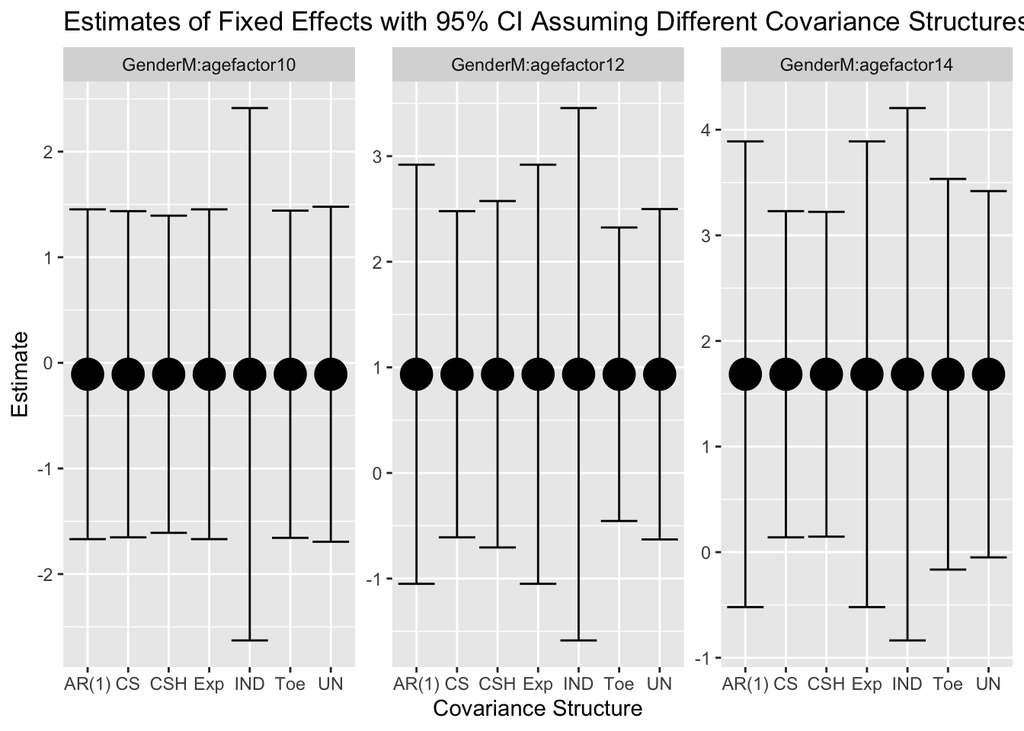

```r
est <- function(model,cov) {
  a <- as.data.frame(intervals(model)$coef)
  a$covstr <- cov
  a$effect <- rownames(a)
  a
}

fixed <- rbind(est(m1,'IND'),est(m2,'UN'),est(m3,'CS'),est(m4,'AR(1)'),
               est(m5,"Toe"),est(m6,'Exp'),est(m7,'CSH'))
fixed1 = fixed[fixed$effect == 'GenderM:agefactor10',]
fixed2 = fixed[fixed$effect == 'GenderM:agefactor12',]
fixed3 = fixed[fixed$effect == 'GenderM:agefactor14',]
fixed = rbind(fixed1,fixed2,fixed3)

library(ggplot2)
p1 <- ggplot(fixed, aes(x=covstr,y=est.))
p1 + facet_wrap(~effect, scales = "free") + geom_point(size=7) +
  geom_errorbar(aes(ymin=lower,ymax=upper)) +
  labs(title="Estimates of Fixed Effects with 95% CI Assuming Different Covariance Structures",
       x="Covariance Structure", y="Estimate")
```

The CI for the IND is the widest. The confidence interval doest not include 0 then it is significant.

4c

The ages is equals spaced so we cannot use the exponential model(m6). Also the model 1 time is relative so it is not independent, so we cannot use the m1.

LRT AIC

```r
anova(m1,m2)
```

```
##    Model df      AIC      BIC    logLik   Test  L.Ratio p-value
## m1     1  9 488.4908 511.9374 -235.2454
## m2     2 18 450.0348 496.9279 -207.0174 1 vs 2 56.45605  <.0001
```

```r
anova(m2,m3)
```

```
##    Model df      AIC      BIC    logLik   Test  L.Ratio p-value
## m2     1 18 450.0348 496.9279 -207.0174
## m3     2 10 443.4085 469.4602 -211.7043 1 vs 2 9.373732  0.3118
```

```r
anova(m2,m4)
```

```
##    Model df      AIC      BIC    logLik   Test  L.Ratio p-value
## m2     1 18 450.0348 496.9279 -207.0174
## m4     2 10 454.5472 480.5989 -217.2736 1 vs 2 20.51236  0.0086
```

```r
anova(m2,m5)
```

```
##    Model df      AIC      BIC    logLik   Test  L.Ratio p-value
## m2     1 18 450.0348 496.9279 -207.0174
## m5     2 12 442.9499 474.2119 -209.4750 1 vs 2 4.915104  0.5547
```

```r
anova(m5,m6)
```

```
##    Model df      AIC      BIC    logLik   Test  L.Ratio p-value
## m5     1 12 442.9499 474.2119 -209.4750
## m6     2 10 454.5472 480.5989 -217.2736 1 vs 2 15.59726   4e-04
```

```r
anova(m5,m7)
```

```
##    Model df      AIC      BIC    logLik   Test  L.Ratio p-value
## m5     1 12 442.9499 474.2119 -209.4750
## m7     2 13 447.4236 481.2908 -210.7118 1 vs 2 2.473695  0.1158
```

model 5 is the best since it has the lowest AIC. m5 <- gls(Dental_growth ~ Gender*agefactor, data=longdata, corr=corARMA(form= ~ Time | ID, p=3, q=0))

5.b.

```r
m5.1 = gls(Dental_growth ~ Gender*agefactor,data=longdata,
         corr=corSymm(form= ~ Time | ID))
m5.2 = gls(Dental_growth ~ Gender+agefactor,data=longdata,
         corr=corSymm(form= ~ Time | ID))
anova(m5.1,m5.2)
```

```
##      Model df      AIC      BIC    logLik   Test  L.Ratio p-value
## m5.1     1 15 445.7642 484.8417 -207.8821
## m5.2     2 12 450.3705 481.9873 -213.1852 1 vs 2 10.60633  0.0141
```

Since 0.01 < 0,05 so reject. we choose the model1 which is Gender*agefactor.

```r
coefficients(m5.1)
```

```
##         (Intercept)             GenderM         agefactor10         agefactor12
##          21.1818182           1.6931818           1.0454545           1.9090909
##         agefactor14 GenderM:agefactor10 GenderM:agefactor12 GenderM:agefactor14
##           2.9090909          -0.1079545           0.9346591           1.6846591
```

The GenderM:agefactor10 coefficient is -0.1079545 which means the interative of GenderM:agefactor10 will decrease when this item increase. Similarly, the agefactor12 coefficient is 1.9090909, which means the agefactor increase 1 the growth will increase 1.9090909. The other will represent the similar meaning in this way.